# Homework Assignment 1

### Merging Data Frames

```
##     tailnum          year                            type
##  N10156 :   1   Min.   :1956   Fixed wing multi engine :3292
##  N102UW :   1   1st Qu.:1997   Fixed wing single engine:  25
##  N103US :   1   Median :2001   Rotorcraft              :   5
##  N104UW :   1   Mean   :2000
##  N10575 :   1   3rd Qu.:2005
##  N105UW :   1   Max.   :2013
##  (Other):3316   NA's   :70
##             manufacturer          model         engines          seats
##  BOEING           :1630   737-7H4    : 361   Min.   :1.000   Min.   :  2.0
##  AIRBUS INDUSTRIE : 400   A320-232   : 256   1st Qu.:2.000   1st Qu.:140.0
##  BOMBARDIER INC   : 368   CL-600-2B19: 171   Median :2.000   Median :149.0
##  AIRBUS           : 336   CL-600-2D24: 123   Mean   :1.995   Mean   :154.3
##  EMBRAER          : 299   737-824    : 122   3rd Qu.:2.000   3rd Qu.:182.0
##  MCDONNELL DOUGLAS: 120   MD-88      : 117   Max.   :4.000   Max.   :450.0
##  (Other)          : 169   (Other)    :2172
##      speed                 engine
##  Min.   : 90.0   4 Cycle      :   2
##  1st Qu.:107.5   Reciprocating:  28
##  Median :162.0   Turbo-fan    :2750
##  Mean   :236.8   Turbo-jet    : 535
##  3rd Qu.:432.0   Turbo-prop   :   2
##  Max.   :432.0   Turbo-shaft  :   5
##  NA's   :3299
```

```
## [1] 284170
```

```
## [1] 27
```

Looking at the arrival delay by manufacturer. We can see that the airlane delay varies wildly. The most positive delay is 30.6451613 and the smallest is -13.3684211

Agusta SPA has the highest delay and american aircraft is the lowest for the delay.

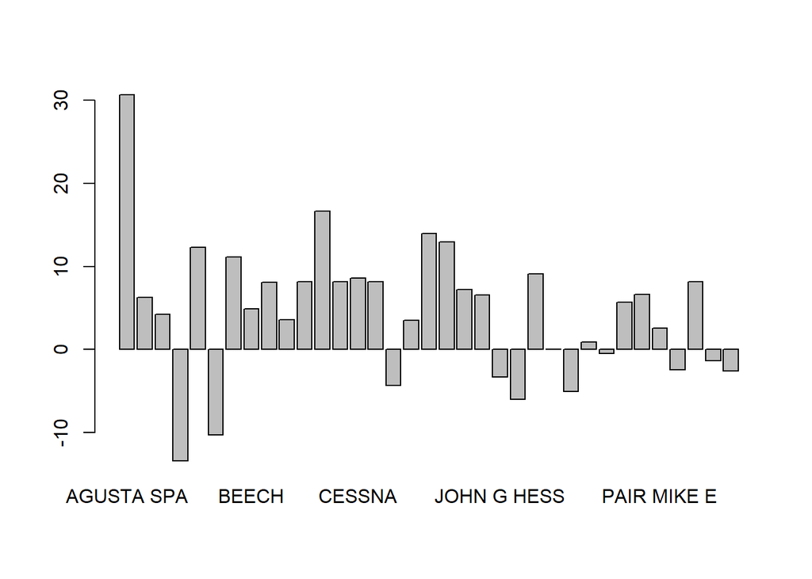

```
## [1] -13.36842
```

```
## [1] 30.64516
```

```
## [1] "AMERICAN AIRCRAFT INC"
```

```
## [1] "AGUSTA SPA"
```

The arrival delay by engine count was also quite telling. Interestingly all engines have positive arrival delay except for airplines with three engines. After digging into the level it seems that 2 engines is extremely common and comprises almost 100% of all levels.

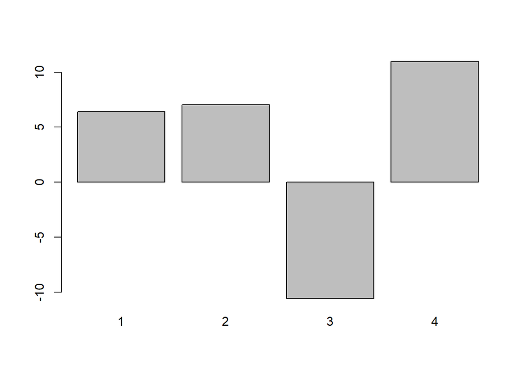

```
## # A tibble: 4 x 2
##   engines no_rows
##   <fct>     <int>
## 1 1          2014
## 2 2        282005
## 3 3             7
## 4 4           144
```

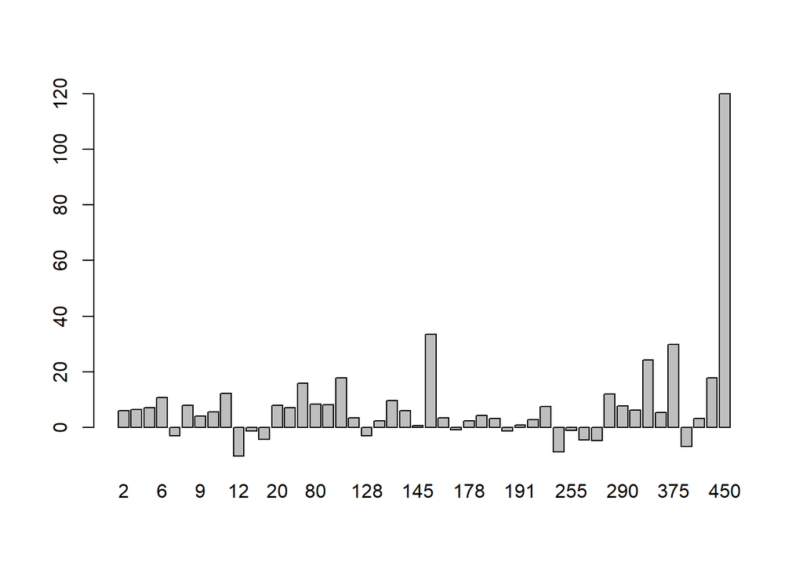

```
## [1] 136.7186
```

When looking at August flights from JFK, I wanted to see the departure delay by manufacturere. while the low value was gulfstream aerospace on average, and the max was aviat aircraft inc. I found that overall there was a postive departure delay across most manufacturers. This makes sense given weather delays and other factors that should impact most carriers.Looking deeper into the data these manufacturers were rare and may explain the high or low mean values.

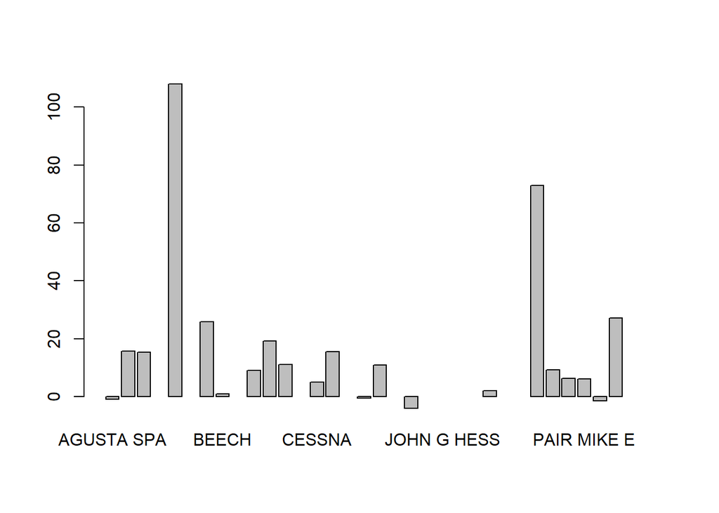

```
## [1] 8512
```

```
## [1] 0
```

```
## [1] 1
```

When looking at arrivals delay by day of the month, there seems to be a pattern where overall after a period of up to 7 days there will be a switch from positive to negative delay.

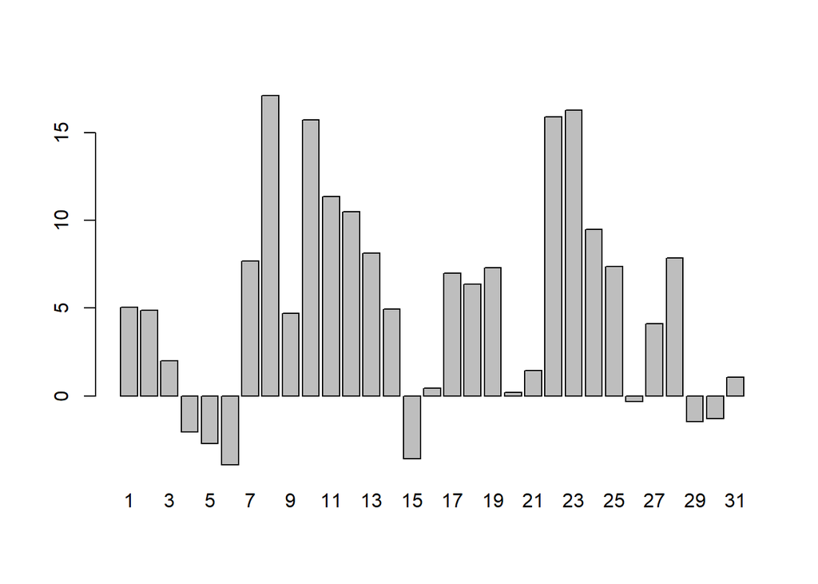

> This section and the next is new compared to the class exercise. As you had an opportunity to work together in your breakout rooms for previous questions, this and the next section will carry a higher weight in grading for this HW.

You can get detailed information about the physical planes in our dataset in this file: `planes.csv`. Download and save this file in your project directory.

1. Read the `planes.csv` file using `read.csv` command. Do any data cleaning necessary.
2. Merge the flights data and the planes data using the `merge` command. You should do the merge on the common column named `tailnum`. *getting this right may need some trial and error and getting some help*.
3. Now that you have a merged dataset, think of what interesting questions that you can ask that can be answered using the merged dataset. You are asked to pose five interesting questions and answer them. (For example: who are the top 10 manufacturers of planes that fly out of NYC airports?) **Be creative. Be bold. Ask questions that you would want to know answers to even if you were not doing this for a HW.**

### Making Your HTML Look Nice

We want our report to be good looking, professional documents. To that end, I am asking you to do the following:

- Have a floating table of contents
- Include code folding in your output. You can find more about code folding here: https://bookdown.org/yihui/rmarkdown/html-document.html#code-folding

That’s it. Once you are done, make sure everything works and knits well and then you can push your changes to the GitHub repo and uplaod the RMD flile and the html output to Canvas.

**Have Fun!**

Sanjeev